# Patient Level Prediction (PLP) Model Analysis Notebook

This notebook demonstrates how to download and analyze the results of successful PLP workflow.

## Installation

```python
!pip install scikit-learn
!pip install numpy
!pip install seaborn
```

## Initial setup

Let's import python libraries:

```python
from sklearn.metrics import roc_auc_score, roc_curve, average_precision_score
import pandas as pd
import seaborn as sns
import joblib
import os
import warnings
import zipfile
import json
import numpy
```

## Download PLP Results

Once your workflow successfully completed, you can download zip archive with initial workflow parameters, training execution logs, trained model PKL file, and training related plots.

To download your trained model, please follow these steps:

- Visit CADC website https://qa-mickey.planx-pla.net/
- If you are not logged in, click **Login** link on the top right conner and log in using your credentials
- Click on the **Apps** icon on the top bar
- Ensure your team selected properly in the **Team Project** field below the top bar. Change your team if needed by clicking **Edit** icon and selecting new team
- Click on the **Results** App
- In the list of workflows find your workflow and click on the corresponding **Results** button, then click **Download All Results**

This will start the downloading process.

Let's unpack zip archive with these simple commands.

Please change initial variables' values accordingly:

```python
# Change path to your download folder path
download_path = '.'

# Change workflow id to workflow id you downloaded
plp_id = 'plp-f95hm'

# Change destination to your prefered destination:
destination_path = "."
```

Unpack downladed zip archive to the specified destination:

```python
zip_path = os.path.expanduser(f'{download_path}/{plp_id}.zip')
destination_path = os.path.expanduser(destination_path)

with zipfile.ZipFile(zip_path) as zip_ref:
    zip_ref.extractall(destination_path)

plp_path = f'{destination_path}/{plp_id}'
```

Check the content:

```python
!ls -la {plp_path}
```

```
total 16
drwxr-sr-x 3 jovyan users 4096 Jul 31 20:52 .
drwxrwsr-x 5 root   users 4096 Jul 31 20:52 ..
drwxr-sr-x 3 jovyan users 4096 Jul 31 20:52 plp_outputs
-rw-r--r-- 1 jovyan users 1286 Jul 31 20:52 workflow_inputs.json
```

PLP results folder contains **workflow_inputs.json** file with input parameters of your PLP worfklow and **plp_output** folder with PLP training results

Review PLP workflow inputs:

```python
with open(f'{plp_path}/workflow_inputs.json') as file:
    plp_inputs = json.load(file)
print(json.dumps(plp_inputs, indent=2))
```

```
{
  "plp_workflow_id": "plp-f95hm",
  "plp_workflow_name": "Random Forest",
  "dataset_id": 200,
  "outcome_id": 233,
  "dataset_observation_window": 365,
  "outcome_observation_window": 3650,
  "require_time_at_risk": false,
  "min_time_at_risk": 364,
  "include_all_outcomes": true,
  "first_exposure_only": false,
  "remove_subjects_with_prior_outcome": true,
  "covariate_min_fraction": 0.001,
  "test_fraction": 0.25,
  "n_fold": 3,
  "model_list": [
    {
      "name": "Random Forest",
      "params": {
        "ntrees": [
          100,
          500
        ],
        "criterion": [
          "gini"
        ],
        "maxDepth": [
          4,
          10,
          17
        ],
        "minSamplesSplit": [
          2
        ],
        "minSamplesLeaf": [
          1,
          10
        ],
        "minWeightFractionLeaf": [
          0
```

[output cut: 13 more lines]

```
        ],
        "maxSamples": [
          0.9
        ],
        "oobScore": [
          false
        ],
        "classWeight": [
          "balanced"
        ],
        "seed": 42
      }
    }
  ]
}
```

Inspect Random Forest output:

```python
!ls -la {plp_path}/plp_outputs/random_forest
```

```
total 100
drwxr-sr-x 4 jovyan users  4096 Jul 31 20:52 .
drwxr-sr-x 3 jovyan users  4096 Jul 31 20:52 ..
drwxr-sr-x 2 jovyan users  4096 Jul 31 20:52 plots
-rw-r--r-- 1 jovyan users 84330 Jul 31 20:52 plpLog.txt
drwxr-sr-x 3 jovyan users  4096 Jul 31 20:52 plpResult
```

## Inspect Plots

inspect plots generated for Random Forest Model under "plots" directory

## Inspect and Analyze Trained Model

For this demonstration, let's analyze Trained Random Forest Model.

Let's set paths to trained model file and to covariate importance file

```python
rf_model_path = f'{plp_path}/plp_outputs/random_forest/plpResult/model/model/model.pkl'
covariates_path = f'{plp_path}/plp_outputs/random_forest/plpResult/model/covariateImportance.csv'
```

Let's load trained model:

```python
# match sklearn version in workflow with the one in notebook
with warnings.catch_warnings():
    warnings.simplefilter("ignore")
    rf_model = joblib.load(rf_model_path)
```

Let's inspect it:

```python
rf_model
```

```
RandomForestClassifier(class_weight='balanced', max_depth=17,
                       max_leaf_nodes=100, max_samples=0.9,
                       min_impurity_decrease=0, min_weight_fraction_leaf=0,
                       random_state=42)
```

### Investigate feature/covariate importances

```python
rf_model.feature_importances_
```

```
array([0.00336668, 0.00718511, 0.00579861, ..., 0.00039204, 0.0012977 ,
       0.0016697 ])
```

```python
len(rf_model.feature_importances_)
```

```
1979
```

```python
covar_importances = pd.read_csv(covariates_path)
```

```python
covar_importances.shape
```

```
(1979, 9)
```

```python
covar_importances.head()
```

|  | covariateId | columnId | covariateName | analysisId | conceptId | valueAsConceptId | collisions | included | covariateValue |
| --- | --- | --- | --- | --- | --- | --- | --- | --- | --- |
| 0 | 4170143212 | 856 | condition_era group (ConditionGroupEraShortTer... | 212 | 4170143 | NaN | NaN | 1 | 0.003367 |
| 1 | 441542212 | 241 | condition_era group (ConditionGroupEraShortTer... | 212 | 441542 | NaN | NaN | 1 | 0.007185 |
| 2 | 4134595212 | 786 | condition_era group (ConditionGroupEraShortTer... | 212 | 4134595 | NaN | NaN | 1 | 0.005799 |
| 3 | 4195061212 | 911 | condition_era group (ConditionGroupEraShortTer... | 212 | 4195061 | NaN | NaN | 1 | 0.019593 |
| 4 | 436940212 | 225 | condition_era group (ConditionGroupEraShortTer... | 212 | 436940 | NaN | NaN | 1 | 0.012093 |

```python
covar_importances['rf_feature_importance'] = rf_model.feature_importances_
```

```python
feat_imp = covar_importances.sort_values(
    by='rf_feature_importance', ascending=False
).head(n=10)
```

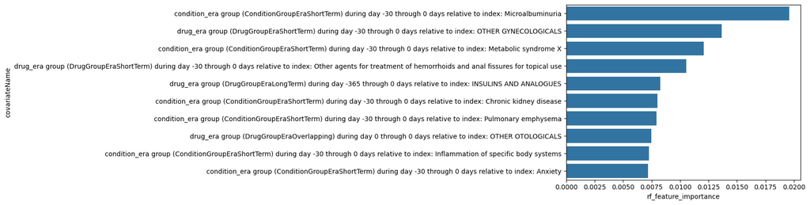

```python
sns.barplot(x='rf_feature_importance',
            y='covariateName',
            data=feat_imp
           )
```